# Causal Inference Final Project

CBPS and Entropy Balancing - A simulation Study

Chansoo Song

December 2018

## Motivation:

A key challenge in the application of propensity scores for matching is that the propensity score is unknown and must be estimated. To make matters worse, slight misspecification of the propensity score model can lead to substantial biases in treatment effects. This has led to researchers iteratively re-estimating the propensity score model, subsequently checking the resulting covariate balance, then repeating over and over until they are satisfied. Imai et al (2008) calls this the ‘propensity score tautology’: the estimated propensity score is appropriate if it balances covariates.

In this simulation study, I analyze two approaches that seek to bypass this ‘propensity score tautology’: Covariate Balancing Propensity Score and Entropy Balancing. Each method obviates the need for iteratively re-estimating the propensity score model and checking balance on the covariate moments. That is, a single model is used to estimate both the treatment assignment mechanism and the covariate balancing weights.

## Assumptions:

#### Matching:

In an observational study setting where the confounding covariates are known and measured, we may use mathching methods to ensure that there is sufficient overlap and balance on these covariates. Then, we can estimate the treatement effect using a simple difference in means or regression methods.

Overlap is important because we want to make sure that for each treated or control subject in the study, there exists an empirical counterfactual (this criteria varies depending on the estimand of interest, i.e. to estimate the ATT it is sufficient to have empirical counterfactuals for just the treated subjects in the study). Balance on the covariates is important because imbalance would force us to rely more on the correct functional form of the model.

There are many different matching methods, but the driving principle is to identify observations that are “most similar”, based on some distance metric. Methods include K-nearest-neighbor, caliper-matching, kernel-matching, Mahalanobis matching, Genetic Matching, Optimal Matching.

#### Propensity Scores:

A propensity score is a one-number summary of the covariates. Rosenbaum and Rubin (1983) define the propensity score for participant i as the conditional probability of treatment assignment $(Z_{i} = 1)$ given a vector of observed covariates: $e(X_{i}) = Pr(Z_{i} = 1 | X)$. The most common traditional approaches to estimating the propensity score are logistic regression and probit regression.

If strong ignorability holds after conditioning on the propensity score, that is:

$$y_{0},y_{1}\ \bot\ Z_{i}|e(X_{i}),\ 0 < e(X_{i}) < 1$$
Then we may obtain an unbiased estimate of the treatment effect by either matching or weighting using just the propensity score instead of the vector of covariates.

## Describe the designs / estimators:

#### Covariate Balancing Propensity Score (CBPS):

The CBPS exploits the dual characteristics of the propensity score as a covariate balancing score and the conditional probability of treatment assignment (Imai and Ratkovic (2012)).

First, consider a commonly used model for estimating propensity scores: logistic regression:

$$e_{B}(X_{i}) = \frac{exp(X_{i}^{T}\beta)}{1+exp(X_{i}^{T}\beta)}$$

We typically estimate the unknown parameters by maximum likelihood, i.e. maximizing the log-likelihood function:

$$\hat{\beta}_{MLE} = \sum_{i=1}^{N}Z_{i}\ log\{e_{B}(X_{i})\ + (1-Z_{i})\ log\{1-e_{B}(X_{i})\}$$
Differentiating with respect to $\beta$, we get:

$$\frac{1}{N}\sum_{i=1}^{N} \frac{Z_i\ e'_{B}(X_{i})}{e_{B}(X_{i})} - \frac{(1-Z_i)\ e'_{B}(X_{i})}{1-e_{B}(X_{i})}$$
Imai and Ratkovic emphasize that the equation above can also be interpreted as the condition that balances a particular function of covariates, i.e. the first derivative of $e_{B}(X_{i})$. Then, they operationalize the covariate balancing property by using inverse propensity score weighting:

$$E\left\{ \frac{Z_i\ e'_{B}(\tilde{X_{i}})}{e_{B}(X_{i})} - \frac{(1-Z_i)\ e'_{B}(\tilde{X_{i}})}{1-e_{B}(X_{i})} \right\} = 0$$
where $\tilde{X_i} = f(X_i)$, a function of $X_i$ specified by the researcher. Setting $\tilde{X_i} = e'_{B}(X_{i})$ gives more weights to covariates that are predictive of treatmeent assignment according to the logistic regression propensity score model. But so long as the expectaion exists, the equation must hold for any choice of f(.). For example, setting $\tilde{X_i} = X_i$ ensures the first moment of each covariate is balanced. Setting $\tilde{X_i} = (X_{i}^TX_i^{2T})^T$ ensures the first and second moment of each covariate is balanced.

#### Entropy Balancing:

Entropy balancing similarly involves a reweighting scheme that directly incorporates covariate balance into the weight function that is applied to the sample units (Heinmueller 2015). To do this, entropy balancing searches for a set of weights that satisfies the balance constraints, while trying to keep the distribution of weights as uniform as possible (i.e. minimizing the divergence of distribution of weights from a uniform distribution). Thus, entropy balancing (1) allows us to obtain a high degree of covariate balance (using balance constraints that can involve the first, second, and possibly higher moments of the covariate distributions as well as interactions). And (2) allows for a more flexible reweighting scheme that seeks to retain as much information as possible. For example, nearest neighbor matching may discard subjects that are not matched (i.e. set weight equal to 0).

Consider the reweighting scheme to estimate the Average Treatement Effect on the Treated (ATT). We would want to estimate the counterfactual mean by:

$$E[\widehat{Y(0)|Z=1}] = \frac{\sum_{i|Z=0}Y_iw_i}{\sum_{i|Z=0}w_i}$$
where $w_i$ is a weight for each control unit.

The weights are chosen by the following reweighting scheme:

$$H(w) = \sum_{i|D=0}h(w_i)$$
where $h(.)$ is a distance metric and $c_{ri}(X_i) = m_r$ describes a set of R balance constraints imposed on the covariate moments of the reweighted control group.

Minimize $H(w)$ subject to the balance and normalizing constraints:

$$\sum_{i|D=0} w_ic_{ri}(X_i) = m_r$$
with $r$ $\in$ $1,..., r$

$$\sum_{i|Z=0}w_i = 1$$
and $w_i \geq 0$ for all $i$ such that $T = 0$.

#### Simulation and DGP Method:

In this section, I examine whether the CBPS or Entropy Balancing methods improve upon the performance of a baseline approach to both (1) achieving balanced covariates and (2) estimating the treatment effect. The baseline approach estimates include (1) propensity scores using logistic regression and matches using 1-1 matching with replacement and (2) mahalanobis matching.

I consider eight data generating processes:

| DGP | Unequal Variances | Incl. Count Covariates | Linear Propensity Score Model |
| --- | --- | --- | --- |
| 1 | 0 | 0 | 1 |
| 2 | 0 | 0 | 0 |
| 3 | 1 | 0 | 1 |
| 4 | 1 | 0 | 0 |
| 5 | 0 | 1 | 1 |
| 6 | 0 | 1 | 0 |
| 7 | 1 | 1 | 1 |
| 8 | 1 | 1 | 0 |

I run each DGP twice, for a total of 16 simulations. For the first set of eight simulations, the true outcome model is a linear regression with the pre-treatment covariates as predictors. For the second set of eight simulations, the true outcome model is a linear regression with non-linear transformations of the pre-treatment covariates as predictors.

## Simulations:

#### Set Up and Initialize:

```r
# Samle size
n = 2000
n_sims = 100

# Models
model_names = c('Baseline Logistic', 'Baseline Mahalanobis',
                'CBPS - Over', 'CBPS - Just',
                'EB - 1', 'EB - 2')
dgp_names = c('std normally dist covs',
              'std normally dist covs (non-linear ps model)',
              'normally dist covs with unequal variances',
              'normally dist covs with unequal variances (non-linear ps model)',
              'std normally dist covs with 3 count covariates',
              'std normally dist covs with 3 count covariates (non-linear ps model)',
              'normally dist covs with unequal var and 3 count covs',
              'normally dist covs with unequal var and 3 count covs (non-linear ps model)')
wts = c('wt','wt_mh',
        'wt.cbps_over','wt.cbps_just',
        'wt.eb','wt.eb2')

# Inverse Logit Function
inv.logit = function (x) {
  y = 1/(1+exp(-x))
  return(y)
}


df = list()
SATE = list()
confounders = list()
for(i in 1:4) confounders[[i]] = paste('z',seq(1,4),sep='')
for(i in 5:8) confounders[[i]] = paste('z',seq(1,7),sep='')
```

#### DGP Function (Pre-Treatment Covariates):

```r
# Function to Generate Pre-Treatment Covariates
dgp = function(n){
  Z_ = list()
  X_ = list()

  # Pre-Treatment covs
  z1 = rnorm(n,  0, 1)
  z2 = rnorm(n,  0, 1)
  z3 = rnorm(n,  0, 1)
  z4 = rnorm(n,  0, 1)

  # DGP 1: std normally dist covs
  Z_[[1]] = cbind(z1, z2, z3, z4)
  X_[[1]] = z1 + z2 + z3 + z4

  # DGP 2: std normally dist covs (non-linear ps model)
  Z_[[2]] = cbind(z1, z2, z3, z4)
  X_[[2]] = -exp(z1/2) - z2/(1+exp(z1)) + z3 - sqrt(z4^2)

  # Pre-Treatment covs
  z1 = rnorm(n,  0, 0.5)
  z2 = rnorm(n,  0, 0.9)
  z3 = rnorm(n,  0, 1.1)
  z4 = rnorm(n,  0, 1.2)

  # DGP 3: normally dist covs with unequal variances
  Z_[[3]] = cbind(z1, z2, z3, z4)
  X_[[3]] = z1 + z2 + z3 + z4

  # DGP 4: normally dist covs with unequal variances (non-linear ps model)
  Z_[[4]] = cbind(z1, z2, z3, z4)
  X_[[4]] = -exp(z1/2) - z2/(1+exp(z1)) + z3 - sqrt(z4^2)

  # Pre-Treatment covs
  z1 = rnorm(n,  0, 1)
  z2 = rnorm(n,  0, 1)
  z3 = rnorm(n,  0, 1)
  z4 = rnorm(n,  0, 1)
  z5 = rpois(n, 1)
  z6 = -rbinom(n, 3, 0.8)
  z7 = rchisq(n, df=1)

  # DGP 5: std normally dist covs with 3 count covs
  Z_[[5]] = cbind(z1, z2, z3, z4, z5, z6, z7)
  X_[[5]] = z1 + z2 + z3 + z4 + z5 + z6 + z7

  # DGP 6: std normally dist covs with 3 count covs (non-linear ps model)
  Z_[[6]] = cbind(z1, z2, z3, z4, z5, z6, z7)
  X_[[6]] = 0.5*exp(z1/2) + z2/(1+exp(z1)) + -.2*z3^2 + z1*z4 -
            0.4*sqrt(z5-z6) - 0.2*(z1+1.2*z6)^2 + 0.5*z7

  # Pre-Treatment covs
  z1 = rnorm(n,  0, 0.5)
  z2 = rnorm(n,  0, 0.9)
  z3 = rnorm(n,  0, 1)
  z4 = rnorm(n,  0, 1.1)
  z5 = rpois(n, 1)
  z6 = -rbinom(n, 2, 0.8)
  z7 = rchisq(n, df=1)

  # DGP 7: normally dist covs with unequal vars and 3 count covs
  Z_[[7]] = cbind(z1, z2, z3, z4, z5, z6, z7)
  X_[[7]] = z1 + z2 + z3 + z4 + z5 + z6 + z7

  # DGP 8: normally dist covs with unequal vars and 3 count covs (non-linear ps model)
  Z_[[8]] = cbind(z1, z2, z3, z4, z5, z6, z7)
  X_[[8]] = 0.5*exp(z1/2) + z2/(1+exp(z1)) -.2*z3^2 + z1*z4 -
            0.4*sqrt(z5-z6) - 0.2*(z1+1.2*z6)^2 + 0.5*z7

  return(list(Z_,X_))
}
```

#### Generate Researcher Dataset Function:

```r
# Function to simulate DGP given pre-treatment covariates
sim_dgp = function(Z_=Z_[[1]], X_=X_[[1]], sim_no=1, n,
                   B_=c(0.4,0.5,0.3,0.9), nlo=FALSE, dgp_name='dgp name here'){

  # Propensity Score
  e_Z = inv.logit(X_)

  # Generate treatment vector
  # treat = as.integer(e_Z>runif(n,0,1))
  treat = rbinom(n,1,prob=e_Z)

  # Treatment Effect
  eff = 4

  if(nlo==FALSE){
    Z_2 = Z_
  }

  if(nlo==TRUE){
    Z_2 = Z_
    Z_2[1] = Z_[1]^2
    Z_2[2] = Z_[2]*Z_[1]
    Z_2[3] = Z_[3]^2
    Z_2[4] = sqrt(Z_[4]^2)
  }

  # Generate Potential Outcomes
  y_0 = Z_2 %*% B_ + rnorm(n,0,1)
  y_1 = Z_2 %*% B_ + eff + rnorm(n,0,1)
  y = y_0*(1-treat) + y_1*treat


  # Generate Researcher Dataset
  df.temp = as.data.frame(cbind(y,y_1,y_0, e_Z, treat, Z_))
  colnames(df.temp)[1:3] = c('y','y_1','y_0')

  return(df.temp)
}
```

```r
dgp_data = dgp(n)
Z_ = dgp_data[[1]]
X_ = dgp_data[[2]]

b_4 = c(0.4,0.5,0.3,0.9)
b_6 = c(0.4,0.5,0.3,0.9,0.1,1,0.3)
B_ = list(b_4,b_4,b_4,b_4,b_6,b_6,b_6,b_6)


for(k in 1:8){
  df[[k]] = sim_dgp(Z=Z_[[k]], X=X_[[k]], sim_no=k,
                    n=n, B_=B_[[k]], dgp_name=dgp_names[k])
  SATE[[k]] = mean(df[[k]]$y_1 - df[[k]]$y_0)

}

# True Propensity Score Density
true_prs_density = list()
for(k in 1:8){
  true_prs_density[[k]] = ggplot(df[[k]], aes(x=e_Z, group=treat, fill = as.factor(treat))) +
    geom_density(alpha=.3) +
    theme_gray() +
    labs(title = paste("Simulation",k),
         subtitle = dgp_names[k],
         caption = "Density of True PS") +
    labs(fill = "Treat") +
    theme(plot.title=element_text(size=8, hjust=0.5, face="bold", colour="maroon")) +
    theme(plot.subtitle=element_text(size=6, face="italic", color="black"))
}
```

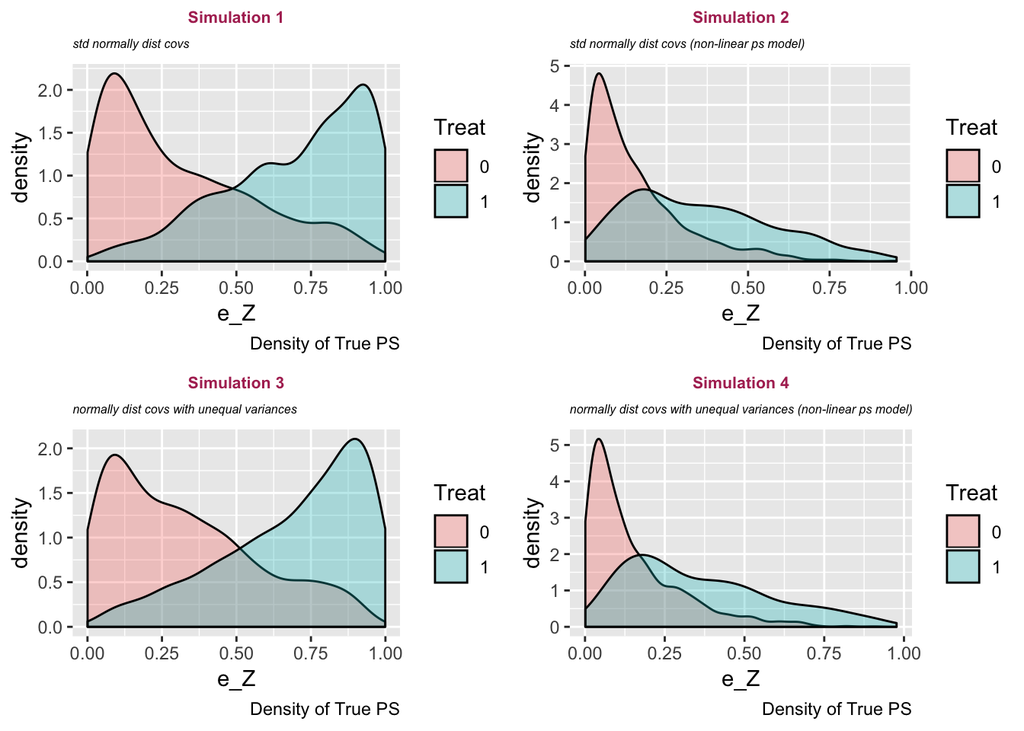

```r
grid.arrange(grobs=true_prs_density[1:4], ncol=2, nrow = 2)
```

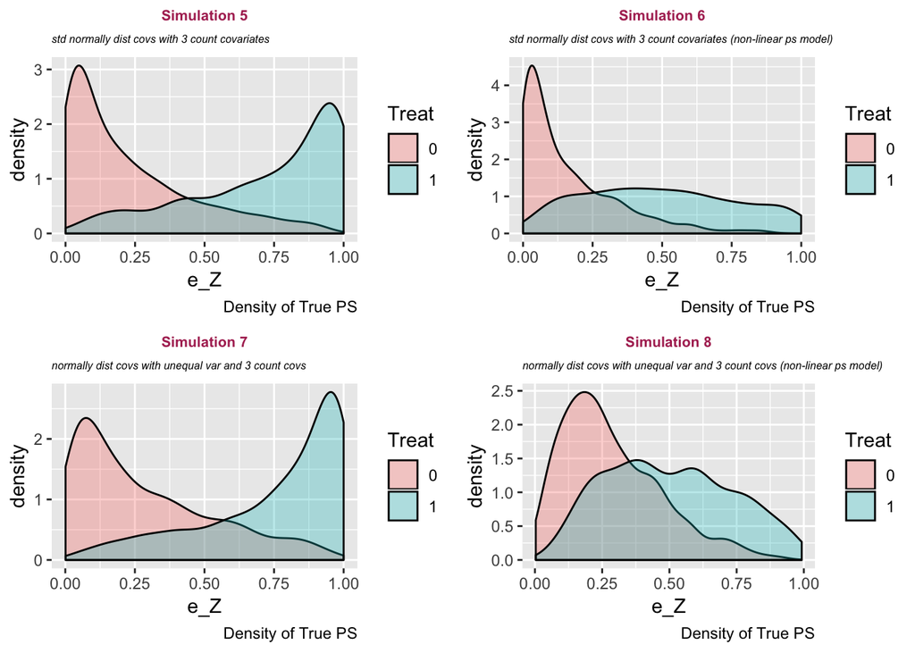

```r
grid.arrange(grobs=true_prs_density[5:8], ncol=2, nrow = 2)
```

#### Matching Methods

1. Baseline: Propensity Score using Logistic Regression:
   - Logistic Regression to estimate propensity scores
   - 1-1 nearest neighbor matching using propensity score
   - linear regression using propensity score and covariates
2. Baseline: Mahalanobis Matching

Mahalanobis calculates distance as $m^2 = (x_T - x_C)'\Sigma_{CR}^{-1}(x_t-x_C)$ and it is equivalent to Euclidean matching based on standardized and orthogonalized X. Mahalanobis was intended for use with multivariate normally distributed data. When some covariates exhibit extreme outliers or very skewed distributions, Mahalanobis distance will place less weight on that covariate. On the other hand, a binary variable with a .99 probability of one would have low standard deviation and the Mahalanobis distance would give greater weight to this variable. One way to address these concerns would be to use ar rank-based Mahalanobis distance. For this simulation study, I use the standard Mahalanobis distance.

3. Covariate Balancing Propensity Score
   - Over-identified: combines the propensity score and covariate balancing conditions
4. Covariate Balancing Propensity Score
   - Just-identified: only contains covariate blancing conditions
5. Entropy Balancing

#### Estimate Weights

```r
mod_match = mod_mahalo = cbps.over = cbps.just = eb.out = eb.out2 = list()

for(k in 1:8){
  formula = as.formula(paste('treat ~ ',paste(confounders[[k]],collapse=' + '),sep=''))

  #### (1)

  # Logistic Regression, 1-1 Matching
  mod_match[[k]] = matchit(formula,
                           data = df[[k]][,c('treat',confounders[[k]])],
                           method = 'nearest',
                           distance = 'logit',
                           replace = TRUE)
  df[[k]]$wt = mod_match[[k]]$weights

  #### (2)

  # Mahalanobis Distance Matching
  mod_mahalo[[k]] = matchit(formula,
                            data = df[[k]][,c('treat',confounders[[k]])],
                            method = "nearest",
                            distance = "mahalanobis",
                            replace = TRUE)
  df[[k]]$wt_mh = mod_mahalo[[k]]$weights

  #### (3)

  # CBPS Weights (OVER)
  cbps.over[[k]]= weightit(formula,
                           data = df[[k]][,c('treat',confounders[[k]])],
                           method = "cbps",
                           estimand = "ATT",
                           over=TRUE)
  df[[k]]$wt.cbps_over = cbps.over[[k]]$weights

  #### (4)

  # CBPS Weights (JUST)
  cbps.just[[k]]= weightit(formula,
                           data = df[[k]][,c('treat',confounders[[k]])],
                           method = "cbps",
                           estimand = "ATT",
                           over=FALSE)
  df[[k]]$wt.cbps_just = cbps.just[[k]]$weights

  #### (5)
  # Entropy Balancing Weights 1
  eb.out[[k]] = ebalance(Treatment = df[[k]]$treat,
                         X = df[[k]][,confounders[[k]]])
  df[[k]]$wt.eb = 1
  df[[k]][df[[k]]$treat == 0,'wt.eb'] = eb.out[[k]]$w

  #### (6)
  # Entropy Balancing Weights 2
  eb.out2[[k]] = ebalance(Treatment = df[[k]]$treat,
                          X = cbind(df[[k]][,confounders[[k]]],
                                    df[[k]][,confounders[[k]]]^2))
  df[[k]]$wt.eb2 = 1
  df[[k]][df[[k]]$treat == 0,'wt.eb2'] = eb.out2[[k]]$w
}
```

#### Examine Overlap of Propensity Score and Covariates (Before Matching)

```r
love.plots=list()

for(k in 1:8){
  formula = as.formula(paste('treat ~ ',paste(confounders[[k]],collapse=' + '),sep=''))
  love.plots[[k]] = love.plot(bal.tab(formula,
                          data = df[[k]][,c('treat',confounders[[k]])],
                          weights = data.frame(Logistic = get.w(mod_match[[k]]),
                                               Mahalanobis = get.w(mod_mahalo[[k]]),
                                               CBPS.over = get.w(cbps.over[[k]]),
                                               CBPS.just = get.w(cbps.just[[k]]),
                                               EB = df[[k]]$wt.eb,
                                               EB2 = df[[k]]$wt.eb2),
                          m.threshold = 0.1),
                  var.order = "unadjusted",
                  abs = FALSE, colors = c("red", "brown", "purple", "cyan",
                                          "blue", "orange", "pink"),
                  shapes = c("circle open", "square open",
                             "square open", "triangle open",
                             "triangle open", "circle open", "diamond open"),
                  stat = c('mean.diffs'),
                  line = TRUE) +
          theme_gray() +
          labs(title=paste('covariate balance: simulation',k),
               subtitle=dgp_names[k]) +
    xlim(-0.52,1)
}
```

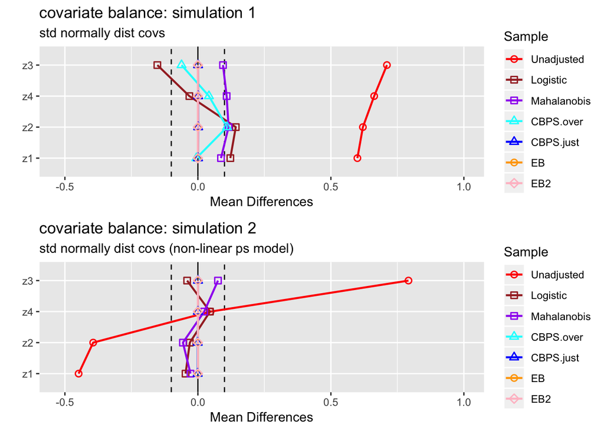

```r
grid.arrange(grobs=love.plots[1:2], ncol=1, nrow = 2)
```

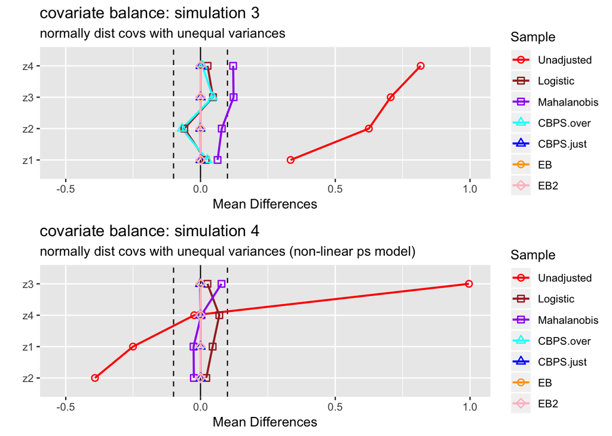

```r
grid.arrange(grobs=love.plots[3:4], ncol=1, nrow = 2)
```

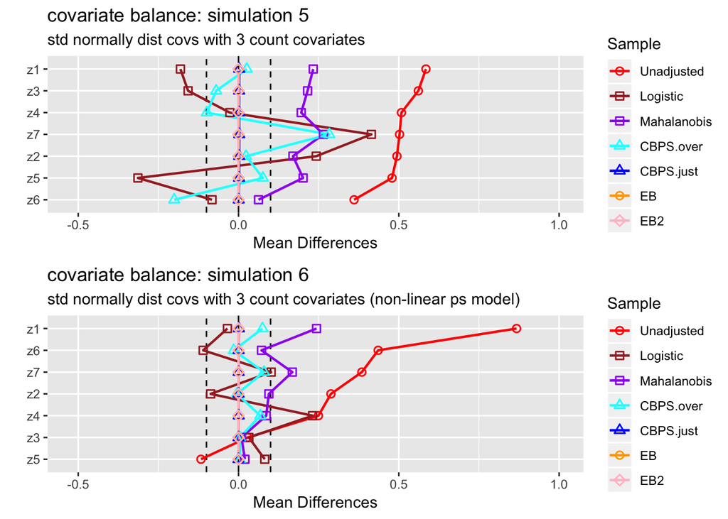

```r
grid.arrange(grobs=love.plots[5:6], ncol=1, nrow = 2)
```

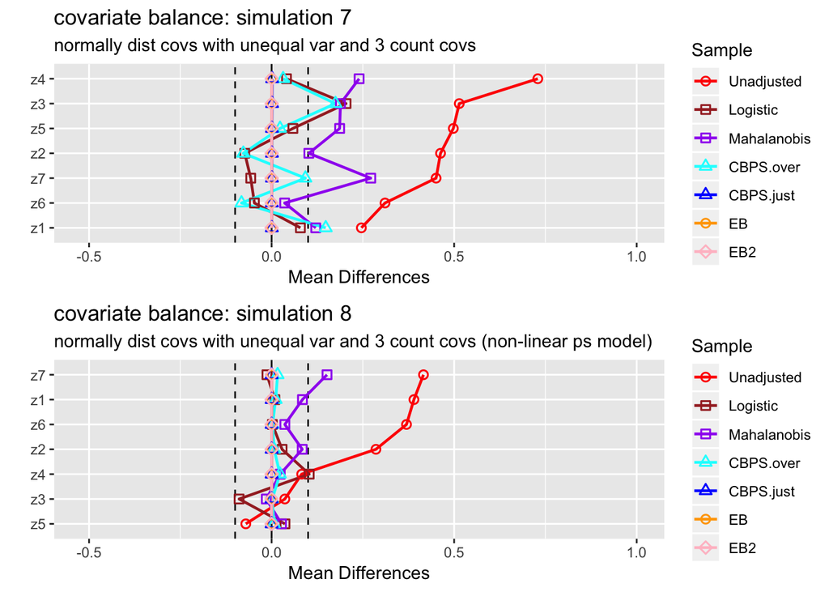

```r
grid.arrange(grobs=love.plots[7:8], ncol=1, nrow = 2)
```

#### Analysis of Mean Differences:

```r
love.plots.var=list()

for(k in 1:8){
  formula = as.formula(paste('treat ~ ',paste(confounders[[k]],collapse=' + '),sep=''))
  love.plots.var[[k]] = love.plot(bal.tab(formula,
                          data = df[[k]][,c('treat',confounders[[k]])],
                          weights = data.frame(Logistic = get.w(mod_match[[k]]),
                                               Mahalanobis = get.w(mod_mahalo[[k]]),
                                               CBPS.over = get.w(cbps.over[[k]]),
                                               CBPS.just = get.w(cbps.just[[k]]),
                                               EB = df[[k]]$wt.eb,
                                               EB2 = df[[k]]$wt.eb2),
                          m.threshold = 0.1),
                  var.order = "unadjusted",
                  abs = FALSE, colors = c("red", "brown", "purple",
                                          "cyan", "blue", "orange", "pink"),
                  shapes = c("circle open", "square open",
                             "square open", "triangle open",
                             "triangle open", "circle open", "diamond open"),
                  stat = c('variance.ratios'),
                  line = TRUE) +
          theme_gray() +
          labs(title=paste('covariate balance: simulation',k),
               subtitle=dgp_names[k])+
  xlim(1,2)
}
```

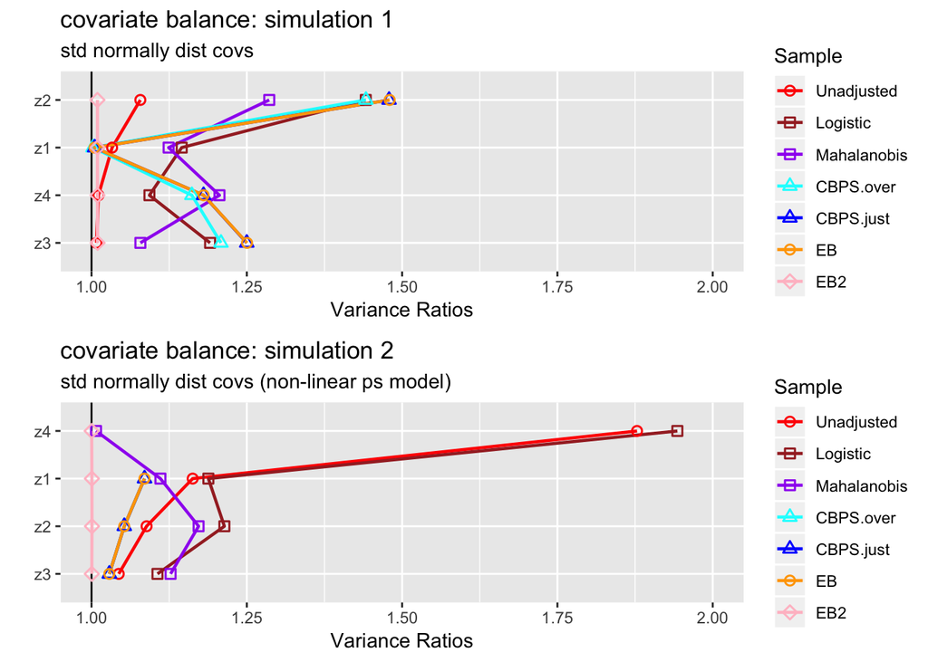

```r
grid.arrange(grobs=love.plots.var[1:2], ncol=1, nrow = 2)
```

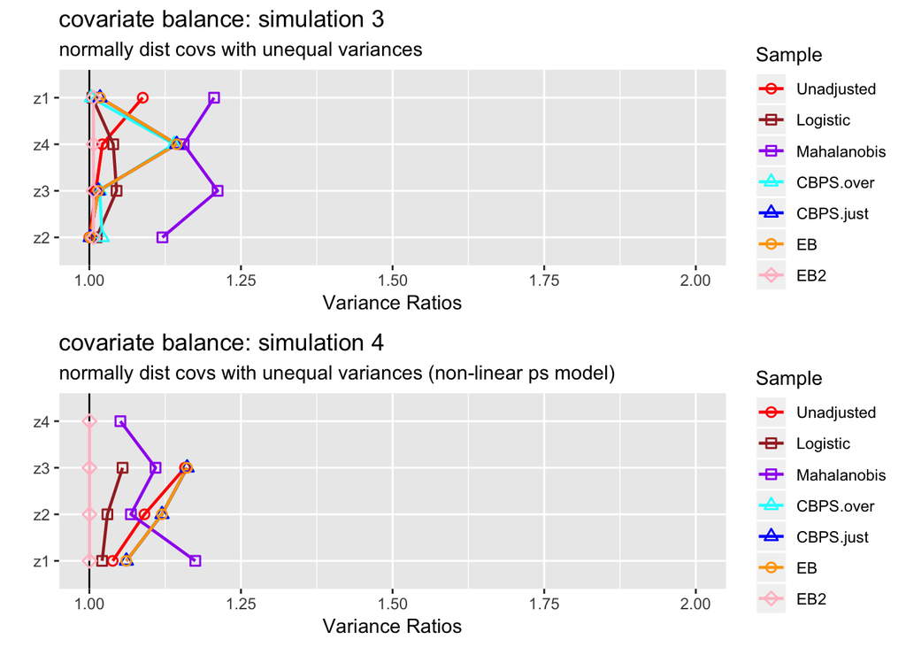

```r
grid.arrange(grobs=love.plots.var[3:4], ncol=1, nrow = 2)
```

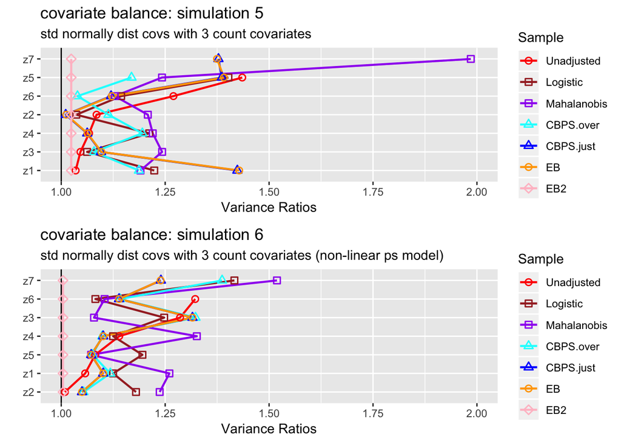

```r
grid.arrange(grobs=love.plots.var[5:6], ncol=1, nrow = 2)
```

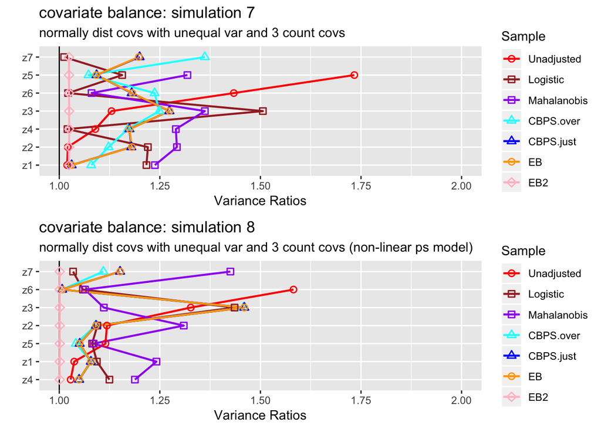

```r
grid.arrange(grobs=love.plots.var[7:8], ncol=1, nrow = 2)
```

#### Analysis of Variance Ratios:

- The Entropy Balancing model where I have set both first and second moment conditions (EB 2) is the only model that consistently achieves variance ratios = 1. The other models’ ability to obtain similar variances of matched samples across treatment groups is rather sporadic.
- Simulations 3/4 and simulations 7/8 are not discernibly different from simulations 1/2 and simulations 5/6. This suggests that unequal variances in the pre-treatment covariates does not impact variance ratios of matched samples.

#### Sampling Distributions of Estimated Treatment Effect

The block of code below was run on HPC clusters to save time, hence eval=FALSE. I load results of models below for analysis.

```r
for(k in 1:8){

  # For Debugging
  print(k)

  # Initialize Matrices to Store Results for Mean Difference and Linear Regression
  md_results  = matrix(nrow=n_sims,
                       ncol=length(model_names),
                       dimnames = list(1:n_sims,model_names))

  lin_results = matrix(nrow=n_sims,
                       ncol=length(model_names),
                       dimnames = list(1:n_sims,model_names))

  df.temp = df[[k]]

  for(i in 1:n_sims){

    formula = as.formula(paste('treat ~ ',paste(confounders[[k]],collapse=' + '),sep=''))

    # Generate treatment vector
    df.temp$treat = as.integer(runif(n) <= df.temp$e_Z)
    df.temp$y = df.temp$y_0*(1-df.temp$treat) + df.temp$y_1*df.temp$treat

    # Logistic Regression, 1-1 Matching
    mod_match = matchit(formula,
                        data = df.temp,
                        method = 'nearest',
                        distance = 'logit',
                        replace = TRUE)
    df.temp$wt = mod_match$weights

    # Mahalanobis Distance Matching
    mod_mahalo = matchit(formula,
                         data = df.temp,
                         method = "nearest",
                         distance = "mahalanobis",
                         replace = TRUE)
    df.temp$wt_mh = mod_mahalo$weights

    # CBPS Weights (OVER)
    cbps.over = weightit(formula,
                         data = df.temp,
                         method = "cbps",
                         estimand = "ATT",
                         over=TRUE)
    df.temp$wt.cbps_over = cbps.over$weights

    # CBPS Weights (JUST)
    cbps.just = weightit(formula,
                         data = df.temp,
                         method = "cbps",
                         estimand = "ATT",
                         over=FALSE)
    df.temp$wt.cbps_just = cbps.just$weights

    # Entropy Balancing Weights 1
    eb.out = ebalance(Treatment = df.temp$treat,
                      X = df.temp[,confounders[[k]]])
    df.temp$wt.eb = 1
    df.temp[df.temp$treat == 0,'wt.eb'] = eb.out$w

    # Entropy Balancing Weights 2
    eb.out2 = ebalance(Treatment = df.temp$treat,
                      X = cbind(df.temp[,confounders[[k]]],
                                df.temp[,confounders[[k]]]^2))
    df.temp$wt.eb2 = 1
    df.temp[df.temp$treat == 0,'wt.eb2'] = eb.out2$w

    # Weighted Mean Differences
    ##############################

    trt=df.temp$treat==1
    ctrl=df.temp$treat==0

    df.trt = df.temp[trt,]
    df.ctrl = df.temp[ctrl,]

    for(j in 1:length(wts)){
      md_results[i,j] = weighted.mean(df.trt$y, df.trt[,wts[j]]) -
        weighted.mean(df.ctrl$y, df.ctrl[,wts[j]])
    }

    # Linear Regression
    ##############################

    for(j in 1:length(wts)){
      lm.mod = lm(y ~ .,
                  data = df.temp[,c('y','treat',confounders[[k]])],
                  weights = df.temp[,wts[j]])
      lin_results[i,j] = summary(lm.mod)$coefficients['treat','Estimate']
    }


  }

  save(lin_results, md_results, SATE,
       file = paste('sim',k,'_n',n,'_nsims',n_sims,'_nlo',nlo,'.RDATA',sep=''))
}
```

#### Analysis of Simulations:

```r
lin_mse1 = lin_bias1 = matrix(nrow=8,
                            ncol=length(model_names),
                            dimnames = list(paste('sim',1:8),model_names))

for(k in 1:8){
  load(paste('sim_results/sim',k,'_n2000_nsims200_nloFALSE.RDATA',sep=''))
  lin_bias1[k,] = (SATE[[k]] - apply(lin_results,2,mean)) / SATE[[k]]
  lin_mse1[k,] = apply((SATE[[k]]-lin_results)^2,2,mean)
}
```

```r
lin_mse2 = lin_bias2 = matrix(nrow=8,
                            ncol=length(model_names),
                            dimnames = list(paste('sim',1:8),model_names))


for(k in 1:8){
  load(paste('sim_results/sim',k,'_n2000_nsims200_nloTRUE.RDATA',sep=''))
  lin_bias2[k,] = (SATE[[k]] - apply(lin_results,2,mean)) / SATE[[k]]
  lin_mse2[k,] = apply((SATE[[k]]-lin_results)^2,2,mean)
}

kable(round(lin_bias1,4),
      caption='Linear Outcome Model -- Linear Regression: Bias')
```

Table 1: Linear Outcome Model – Linear Regression: Bias

|  | Baseline Logistic | Baseline Mahalanobis | CBPS - Over | CBPS - Just | EB - 1 | EB - 2 |
| --- | --- | --- | --- | --- | --- | --- |
| sim 1 | 0.0064 | 0.0110 | 0.0076 | 0.0075 | 0.0075 | 0.0085 |
| sim 2 | -0.0004 | 0.0049 | 0.0012 | 0.0012 | 0.0012 | 0.0018 |
| sim 3 | 0.0002 | -0.0014 | -0.0001 | 0.0001 | 0.0001 | 0.0008 |
| sim 4 | -0.0006 | -0.0077 | -0.0031 | -0.0031 | -0.0031 | -0.0091 |
| sim 5 | -0.0019 | 0.0032 | -0.0032 | -0.0045 | -0.0047 | -0.0059 |
| sim 6 | -0.0094 | -0.0073 | -0.0092 | -0.0092 | -0.0092 | -0.0109 |
| sim 7 | -0.0054 | 0.0071 | -0.0026 | -0.0050 | -0.0052 | -0.0053 |
| sim 8 | 0.0086 | 0.0020 | 0.0091 | 0.0095 | 0.0095 | 0.0056 |

```r
kable(sqrt(round(lin_mse1,4)),
      caption='Linear Outcome Model -- Linear Regression: RMSE')
```

Table 1: Linear Outcome Model – Linear Regression: RMSE

|  | Baseline Logistic | Baseline Mahalanobis | CBPS - Over | CBPS - Just | EB - 1 | EB - 2 |
| --- | --- | --- | --- | --- | --- | --- |
| sim 1 | 0.1224745 | 0.0888819 | 0.0964365 | 0.1004988 | 0.1004988 | 0.1014889 |
| sim 2 | 0.0774597 | 0.0761577 | 0.0500000 | 0.0500000 | 0.0500000 | 0.0556776 |
| sim 3 | 0.1170470 | 0.0734847 | 0.0830662 | 0.0866025 | 0.0866025 | 0.0894427 |
| sim 4 | 0.0812404 | 0.0800000 | 0.0556776 | 0.0556776 | 0.0556776 | 0.0692820 |
| sim 5 | 0.1565248 | 0.0663325 | 0.1183216 | 0.1371131 | 0.1392839 | 0.1417745 |
| sim 6 | 0.0848528 | 0.0728011 | 0.0632456 | 0.0632456 | 0.0632456 | 0.0670820 |
| sim 7 | 0.1705872 | 0.0728011 | 0.1200000 | 0.1421267 | 0.1435270 | 0.1714643 |
| sim 8 | 0.0806226 | 0.0591608 | 0.0591608 | 0.0608276 | 0.0608276 | 0.0624500 |

```r
kable(round(lin_bias2,4),
      caption='Non-Linear Outcome Model -- Linear Regression: Bias')
```

Table 1: Non-Linear Outcome Model – Linear Regression: Bias

|  | Baseline Logistic | Baseline Mahalanobis | CBPS - Over | CBPS - Just | EB - 1 | EB - 2 |
| --- | --- | --- | --- | --- | --- | --- |
| sim 1 | 0.0064 | 0.0110 | 0.0076 | 0.0075 | 0.0075 | 0.0085 |
| sim 2 | -0.0004 | 0.0049 | 0.0012 | 0.0012 | 0.0012 | 0.0018 |
| sim 3 | 0.0002 | -0.0014 | -0.0001 | 0.0001 | 0.0001 | 0.0008 |
| sim 4 | -0.0006 | -0.0077 | -0.0031 | -0.0031 | -0.0031 | -0.0091 |
| sim 5 | -0.0019 | 0.0032 | -0.0032 | -0.0045 | -0.0047 | -0.0059 |
| sim 6 | -0.0094 | -0.0073 | -0.0092 | -0.0092 | -0.0092 | -0.0109 |
| sim 7 | 0.0064 | 0.0047 | 0.0073 | 0.0092 | 0.0096 | 0.0085 |
| sim 8 | 0.0119 | 0.0142 | 0.0107 | 0.0111 | 0.0111 | 0.0122 |

```r
kable(sqrt(round(lin_mse2,4)),
      caption='Non-Linear Outcome Model -- Linear Regression: RMSE')
```

Table 1: Non-Linear Outcome Model – Linear Regression: RMSE

|  | Baseline Logistic | Baseline Mahalanobis | CBPS - Over | CBPS - Just | EB - 1 | EB - 2 |
| --- | --- | --- | --- | --- | --- | --- |
| sim 1 | 0.1224745 | 0.0888819 | 0.0964365 | 0.1004988 | 0.1004988 | 0.1014889 |
| sim 2 | 0.0774597 | 0.0761577 | 0.0500000 | 0.0500000 | 0.0500000 | 0.0556776 |
| sim 3 | 0.1170470 | 0.0734847 | 0.0830662 | 0.0866025 | 0.0866025 | 0.0894427 |
| sim 4 | 0.0812404 | 0.0800000 | 0.0556776 | 0.0556776 | 0.0556776 | 0.0692820 |
| sim 5 | 0.1565248 | 0.0663325 | 0.1183216 | 0.1371131 | 0.1392839 | 0.1417745 |
| sim 6 | 0.0848528 | 0.0728011 | 0.0632456 | 0.0632456 | 0.0632456 | 0.0670820 |
| sim 7 | 0.2002498 | 0.0741620 | 0.1371131 | 0.1679286 | 0.1711724 | 0.1852026 |
| sim 8 | 0.0787401 | 0.0800000 | 0.0624500 | 0.0648074 | 0.0648074 | 0.0734847 |

Above, the first two tables display results: (1) Bias and (2) MSE for 8 different simulations for which the true outcome model is linear. The third and fourth tables show the equivalent results, except with a non-linear true outcome model.

For the first set of simulations (linear true outcome model), the Mahalanobis model has the lowest RMSE for 5 out of 8 simulations. The Mahalanobis model performs particularly well when the true propensity score model is linear and generally performs worse than other models when the true propensity score model is non-linear. The CBPS and EB models generally do well, except for simulations #5 and #7. What’s odd is that simulations #5 and #7 are equivalent to #6 and #8, except that the true propensity score model is NON-linear for #6 and #8. So the intuitive expectation would be that the models would perform better and not worse when the true propensity score model is linear. The baseline logistic model exhibits this pattern as well.

## Application to IHDP Data:

In this section, I apply the matching and reweighting methods to evaluate the Infant Health and Development Program (IHDP).

The dataset for this section is from homework 4. The dataset contains personal details about approximately 4500 children born in the 1980s and their mothers. Of these 4500, 290 received the treatment: IHDP. IHDP provides special services for the children who receive treatment, such as high-quality child care in the second and third years of life. Treatment was not randomly assigned, but rather, to children who were born (1) prematurely, (2) with low birth weight (1500-2500 grams), and (3) lived in one of the eight cities where the intervention took place. The outcome of interest is a test score conducted at age 3 (similar to an IQ measure).

```r
load('data/hw4.Rdata')
df.ihdp = hw4

col_names = colnames(df.ihdp)
cols_to_keep = col_names[!col_names %in% c('treat','ppvtr.36','white',
                                           'ltcoll','bwg','momed','st99')]
ihdp.formula = formula(paste('treat ~ ',paste(cols_to_keep,collapse = ' + ')))

# Logistic Regression, 1-1 Matching
ihdp.log = matchit(ihdp.formula,
                   data = df.ihdp,
                   method = 'nearest',
                   distance = 'logit',
                   replace = TRUE)
df.ihdp$wt = ihdp.log$weights

# Mahalanobis Distance Matching
ihdp.mh = matchit(ihdp.formula,
                  data = df.ihdp,
                  method = "nearest",
                  distance = "mahalanobis",
                  replace = TRUE)
df.ihdp$wt_mh = ihdp.mh$weights

# CBPS Weights (OVER)
ihdb.cbps_o = weightit(ihdp.formula,
                       data = df.ihdp,
                       method = "cbps",
                       estimand = "ATT",
                       over=TRUE)
df.ihdp$wt.cbps_over = ihdb.cbps_o$weights

# CBPS Weights (JUST)
ihdb.cbps_j = weightit(ihdp.formula,
                       data = df.ihdp,
                       method = "cbps",
                       estimand = "ATT",
                       over=FALSE)
df.ihdp$wt.cbps_just = ihdb.cbps_j$weights

# Entropy Balancing Weights
ihdp.eb = ebalance(Treatment = df.ihdp$treat,
                   X = df.ihdp[,cols_to_keep])
df.ihdp$wt.eb = 1
df.ihdp[df.ihdp$treat == 0,'wt.eb'] = ihdp.eb$w
```

```r
ihdp_plot = love.plot(bal.tab(covs = df.ihdp[,cols_to_keep],
                  treat = df.ihdp$treat,
                  data = df.ihdp[,c('treat',cols_to_keep)],
                  weights = data.frame(Logistic = get.w(ihdp.log),
                                       Mahalanobis = get.w(ihdp.mh),
                                       CBPS_j = get.w(ihdb.cbps_j),
                                       CBPS_o = get.w(ihdb.cbps_o),
                                       EB = df.ihdp$wt.eb)),
          var.order = "unadjusted",
          abs = TRUE,
          line = TRUE,
          colors = c("red", "blue", "purple",
                     "darkgreen","brown", "orange"),
          shapes = c("circle open", "square open",
                     "triangle open","triangle open",
                     "circle open", "diamond open")) +
  xlim(0,0.75) +
  labs(title=paste('covariate balance: ihdp data')) +
  aes(alpha=0.7)
```

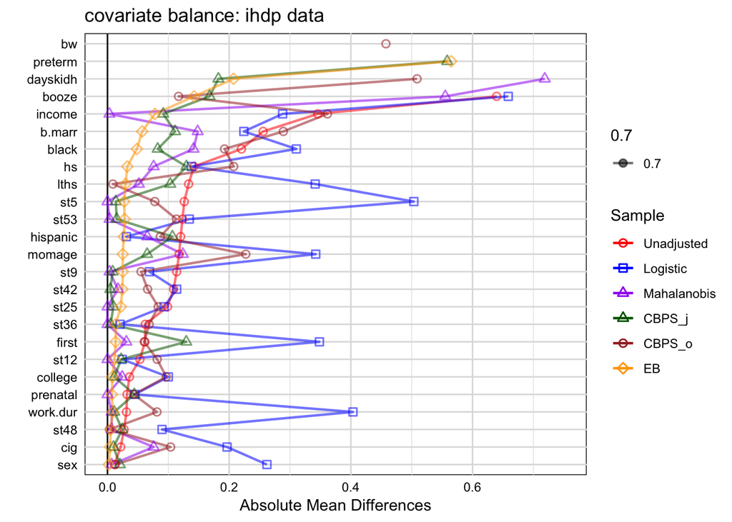

```r
print(ihdp_plot)
```

Simular to the results from the previous simulations, the entropy balancing model achieves the best balance on the covariates.

```r
# Linear Regression
##############################
wts2 = c('wt','wt_mh','wt.cbps_over','wt.cbps_just','wt.eb')
ihdp_lin_b = ihdp_lin_se = c()
for(j in 1:length(wts2)){
  lm.mod = lm(ppvtr.36 ~ .,
              data = df.ihdp[,c('ppvtr.36','treat',cols_to_keep)],
              weights = df.ihdp[,wts2[j]])
  ihdp_lin_b[j] = summary(lm.mod)$coefficients['treat','Estimate']
  ihdp_lin_se[j] = summary(lm.mod)$coefficients['treat','Std. Error']
}

ihdp_results = rbind(ihdp_lin_b,ihdp_lin_se)
colnames(ihdp_results) = model_names[1:5]
```

```r
kable(ihdp_results)
```

|  | Baseline Logistic | Baseline Mahalanobis | CBPS - Over | CBPS - Just | EB - 1 |
| --- | --- | --- | --- | --- | --- |
| ihdp_lin_b | 10.400352 | 5.994024 | 7.4173014 | 15.5415627 | 9.5612430 |
| ihdp_lin_se | 3.445996 | 2.649219 | 0.7729403 | 0.9819042 | 0.6288457 |

```r
save(true_prs_density, love.plots, love.plots.var, ihdp_plot, ihdp_results, file='sim_study_plots.RDATA')
```

## Conclusion and Limitations: